# Manejo de datos

Dr. Jorge Schleef

# Tidyverse

[figure not shown]

El tidyverse es un conjunto de paquetes de R que comparten una estructura y gramática subyacente.

Permite realizar la mayoría de tareas rutinarias de análisis de datos (importación, manejo, visualización y reporte).

# Tidyverse

Las librerías del tidyverse siguen cuatro principios:

**a. Foco centrado en el humano:** busca facilitar el uso de R en usuarios nuevos sin experiencia en programación.

**b. Consistencia:** Lo aprendido sobre una función o librería se puede aplicar en otra.

**c. Compuesto:** ayuda a resolver problemas complejos reduciéndolos a piezas más pequeñas.

**d. Inclusión:** las personas que lo implementan forman una comunidad.

# Paquete dplyr

**dplyr** contiene funciones para manejar y transformar datos.

Cada función de dplyr se puede pensar como un **verbo** que actúa sobre un objeto (dataset).

```r
# Instalar tidyverse

# install.packages("tidyverse)

# También es posible instalar específicamente dplyr

# install.packages("dplyr")

library(dplyr)
```

# Paquete dplyr

Al activar dplyr, se **sobrescriben** algunas funciones de R base u otras librerías (**enmascaramiento**).

Por ejemplo, dplyr tiene una función **select()** que **no** opera de la misma forma que la función **select()** de R base.

Para usar una función de un paquete específico se utiliza **nombre_del_paquete::**. Las funciones de R base pertenecen al paquete **stats**.

```r
# dplyr:: select()

# stats:: select()
```

# Paquete dplyr

La mayoría de tareas básicas de manejo de datos se pueden realizar con cinco verbos de dplyr:

- **filter()** selecciona casos (filas) según sus valores de una o más variables.
- **arrange()** reordena las filas.
- **select()** selecciona variables por su nombre.
- **mutate()** crea nuevas variables a partir de variables existentes.
- **summarize()** colapsa valores en un único resumen.

# Paquete dplyr

Los verbos de dplyr tienen en común que:

- El primer argumento es el objeto con los datos (dataframe).
- El siguiente argumento describe lo que se hará con los datos usando los nombres de las variables sin comillas.
- El resultado es un nuevo dataframe.

Los verbos de dplyr toman el dataset, aplican funciones sobre el mismo, y generan un nuevo dataset modificado.

Sin embargo, dplyr **nunca** modifica el dataset original.

Para guardar el resultado de aplicar un verbo de dplyr se debe asignar a un nuevo objeto.

# Paquete dplyr

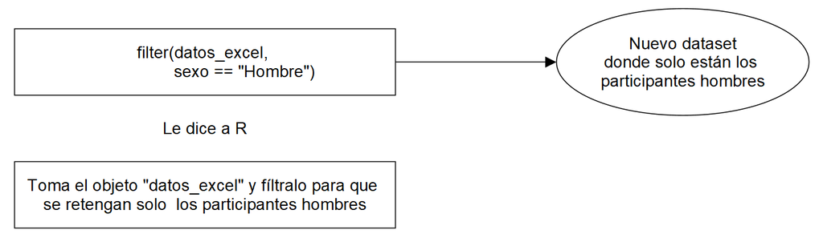

Este código genera un nuevo dataset filtrado, pero **no lo almacena**.

# Paquete dplyr

Para almacenar y utilizar el dataset filtrado se debe asignar a un nuevo objeto.

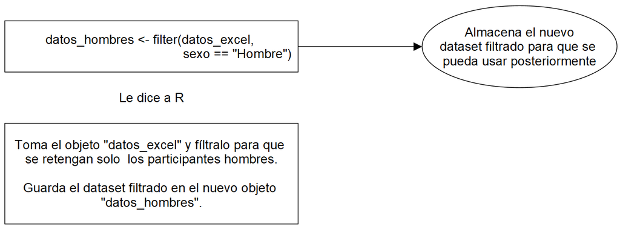

# Datos de ejemplo

| Variable | Etiqueta | Codificación |
| --- | --- | --- |
| ID | Número de identificación |  |
| sexo | Sexo del participante | Hombre, Mujer |
| edad | Edad en años |  |
| hijos | Tiene hijos | Sí, No |
| educacion | Nivel educativo | Básica incompleta - Superior completa |
| actividad | Actividad principal | Trabaja, estudia, desempleado, jefe de hogar |
| civil | Estado civil | Soltero, Casado, Viudo, Divorciado |
| satisfaccion1 | Mi vida, en casi todo, responde a mis aspiraciones | Totalmente en desacuerdo - Totalmente de acuerdo |
| satisfaccion2 | Las condiciones de mi vida son excelentes | Totalmente en desacuerdo - Totalmente de acuerdo |
| satisfaccion3 | Hasta el momento, he conseguido las cosas importantes que quiero en la vida | Totalmente en desacuerdo - Totalmente de acuerdo |
| satisfaccion4 | Si pudiera volver a vivir mi vida, no cambiaría casi nada | Totalmente en desacuerdo - Totalmente de acuerdo |
| satisfaccion5 | Estoy satisfecho con mi vida | Totalmente en desacuerdo - Totalmente de acuerdo |
| apoyo1 | Alguien ha estado disponible para escucharme | Nunca - Siempre |
| apoyo2 | Alguien ha estado disponible para darme consejos | Nunca - Siempre |
| apoyo3 | Alguien ha estado disponible para darme afecto/cariño | Nunca - Siempre |
| apoyo4 | Alguien ha estado disponible para ayudarme con mis obligaciones/tareas | Nunca - Siempre |
| apoyo5 | Alguien ha estado disponible para darme apoyo emocional | Nunca - Siempre |
| apoyo6 | He estado en contacto con alguien en quien puedo confiar | Nunca - Siempre |
| felicidad1 | En general me considero… | No muy feliz - Muy feliz |
| felicidad2 | En comparación con la mayoría de mis iguales, me considero… | No muy feliz - Muy feliz |
| felicidad3 | Soy muy feliz, independientemente de lo que suceda | No me describe en absoluto - Me describe completamente |
| felicidad4 | Con respecto a la vida en general, estás… | No me describe en absoluto - Me describe completamente |
| glucosa_ayuna | Glucosa en ayuna |  |
| IMC | Índice de masa corporal |  |
| AF | Cumple o no con las recomendaciones de actividad física | Sí, No |

**Nota:** Los datos perdidos se codificaron como **-999**.

# Datos de ejemplo

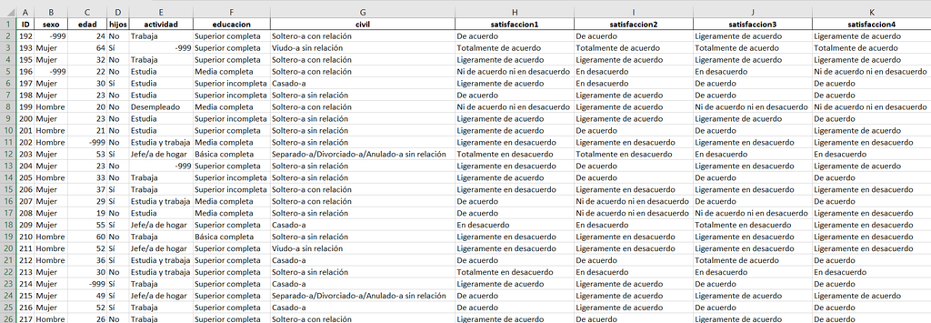

```r
library(readxl)
datos <- read_xlsx("datos_inicio.xlsx")
```

# filter()

Permite crear subconjuntos de filas (casos) según los valores de columnas (variables).

El primer argumento es el nombre del dataframe. El segundo y tercer argumento son expresiones que filtran el dataset.

El filtrado se realiza usando operadores lógicos:

- >
- >=
- <
- <=
- == (igual)
- != (no es igual)

# filter()

Se retienen todos los participantes hombres.

```r
filter(datos,
       sexo == "Hombre")
```

```
## # A tibble: 119 × 25
##       ID sexo   edad hijos actividad educacion civil satisfaccion1 satisfaccion2
##    <dbl> <chr> <dbl> <chr> <chr>     <chr>     <chr> <chr>         <chr>
##  1   199 Homb…    20 No    Desemple… Media co… Solt… Ni de acuerd… Ligeramente …
##  2   201 Homb…    21 No    Estudia   Superior… Solt… Ligeramente … De acuerdo
##  3   202 Homb…  -999 No    Estudia … Media co… Solt… Ligeramente … Ligeramente …
##  4   205 Homb…    33 No    Trabaja   Superior… Solt… Ligeramente … De acuerdo
##  5   210 Homb…    60 No    Trabaja   Básica c… Solt… Ligeramente … Ligeramente …
##  6   211 Homb…    52 Sí    Jefe/a d… Superior… Viud… Ligeramente … Ligeramente …
##  7   212 Homb…    36 Sí    Estudia … Superior… Casa… De acuerdo    De acuerdo
##  8   217 Homb…    26 No    Trabaja   Superior… Solt… Ligeramente … De acuerdo
##  9   224 Homb…    35 Sí    Trabaja   Media co… Casa… Ni de acuerd… Ligeramente …
## 10   225 Homb…    38 Sí    Trabaja   Superior… Casa… Totalmente d… De acuerdo
## # ℹ 109 more rows
## # ℹ 16 more variables: satisfaccion3 <chr>, satisfaccion4 <chr>,
## #   satisfaccion5 <chr>, apoyo1 <chr>, apoyo2 <chr>, apoyo3 <chr>,
## #   apoyo4 <chr>, apoyo5 <chr>, apoyo6 <chr>, felicidad1 <chr>,
## #   felicidad2 <chr>, felicidad3 <chr>, felicidad4 <chr>, glucosa_ayuna <dbl>,
## #   IMC <dbl>, AF <dbl>
```

Se retienen todos los participantes con edades iguales o mayores a 25 años.

```r
filter(datos,
       edad >= 25)
```

```
## # A tibble: 240 × 25
##       ID sexo   edad hijos actividad educacion civil satisfaccion1 satisfaccion2
##    <dbl> <chr> <dbl> <chr> <chr>     <chr>     <chr> <chr>         <chr>
##  1   193 Mujer    64 Sí    -999      Superior… Viud… Totalmente d… Totalmente d…
##  2   195 Mujer    32 No    Trabaja   Superior… Solt… Ligeramente … Ligeramente …
##  3   197 Mujer    30 Sí    Estudia   Superior… Casa… Ligeramente … En desacuerdo
##  4   203 Mujer    53 Sí    Jefe/a d… Básica c… Sepa… Totalmente e… Totalmente e…
##  5   205 Homb…    33 No    Trabaja   Superior… Solt… Ligeramente … De acuerdo
##  6   206 Mujer    37 Sí    Trabaja   Superior… Solt… Ligeramente … Ligeramente …
##  7   207 Mujer    29 Sí    Estudia … Media co… Solt… De acuerdo    Ni de acuerd…
##  8   209 Mujer    55 Sí    Jefe/a d… Superior… Casa… En desacuerdo En desacuerdo
##  9   210 Homb…    60 No    Trabaja   Básica c… Solt… Ligeramente … Ligeramente …
## 10   211 Homb…    52 Sí    Jefe/a d… Superior… Viud… Ligeramente … Ligeramente …
## # ℹ 230 more rows
## # ℹ 16 more variables: satisfaccion3 <chr>, satisfaccion4 <chr>,
## #   satisfaccion5 <chr>, apoyo1 <chr>, apoyo2 <chr>, apoyo3 <chr>,
## #   apoyo4 <chr>, apoyo5 <chr>, apoyo6 <chr>, felicidad1 <chr>,
## #   felicidad2 <chr>, felicidad3 <chr>, felicidad4 <chr>, glucosa_ayuna <dbl>,
## #   IMC <dbl>, AF <dbl>
```

# ¿Se pueden hacer las dos cosas al mismo tiempo?

Se pueden combinar condiciones de filtrado utilizando **operadores Booleanos**:

- & significa **y**.
- | significa **o**.

Se retienen todos los participantes hombres **y** que tienen edades iguales o mayores a 25 años.

```r
filter(datos,
       sexo == "Hombre" & edad >= 25)
```

```
## # A tibble: 90 × 25
##       ID sexo   edad hijos actividad educacion civil satisfaccion1 satisfaccion2
##    <dbl> <chr> <dbl> <chr> <chr>     <chr>     <chr> <chr>         <chr>
##  1   205 Homb…    33 No    Trabaja   Superior… Solt… Ligeramente … De acuerdo
##  2   210 Homb…    60 No    Trabaja   Básica c… Solt… Ligeramente … Ligeramente …
##  3   211 Homb…    52 Sí    Jefe/a d… Superior… Viud… Ligeramente … Ligeramente …
##  4   212 Homb…    36 Sí    Estudia … Superior… Casa… De acuerdo    De acuerdo
##  5   217 Homb…    26 No    Trabaja   Superior… Solt… Ligeramente … De acuerdo
##  6   224 Homb…    35 Sí    Trabaja   Media co… Casa… Ni de acuerd… Ligeramente …
##  7   225 Homb…    38 Sí    Trabaja   Superior… Casa… Totalmente d… De acuerdo
##  8   235 Homb…    34 No    Trabaja   Superior… Solt… De acuerdo    De acuerdo
##  9   239 Homb…    26 No    Trabaja   Superior… Solt… De acuerdo    De acuerdo
## 10   240 Homb…    32 No    Trabaja   Superior… Solt… De acuerdo    De acuerdo
## # ℹ 80 more rows
## # ℹ 16 more variables: satisfaccion3 <chr>, satisfaccion4 <chr>,
## #   satisfaccion5 <chr>, apoyo1 <chr>, apoyo2 <chr>, apoyo3 <chr>,
## #   apoyo4 <chr>, apoyo5 <chr>, apoyo6 <chr>, felicidad1 <chr>,
## #   felicidad2 <chr>, felicidad3 <chr>, felicidad4 <chr>, glucosa_ayuna <dbl>,
## #   IMC <dbl>, AF <dbl>
```

Se retienen todos los participantes hombres **o** que tienen edades iguales o mayores a 25 años.

```r
filter(datos,
       sexo == "Hombre" | edad >= 25)
```

```
## # A tibble: 269 × 25
##       ID sexo   edad hijos actividad educacion civil satisfaccion1 satisfaccion2
##    <dbl> <chr> <dbl> <chr> <chr>     <chr>     <chr> <chr>         <chr>
##  1   193 Mujer    64 Sí    -999      Superior… Viud… Totalmente d… Totalmente d…
##  2   195 Mujer    32 No    Trabaja   Superior… Solt… Ligeramente … Ligeramente …
##  3   197 Mujer    30 Sí    Estudia   Superior… Casa… Ligeramente … En desacuerdo
##  4   199 Homb…    20 No    Desemple… Media co… Solt… Ni de acuerd… Ligeramente …
##  5   201 Homb…    21 No    Estudia   Superior… Solt… Ligeramente … De acuerdo
##  6   202 Homb…  -999 No    Estudia … Media co… Solt… Ligeramente … Ligeramente …
##  7   203 Mujer    53 Sí    Jefe/a d… Básica c… Sepa… Totalmente e… Totalmente e…
##  8   205 Homb…    33 No    Trabaja   Superior… Solt… Ligeramente … De acuerdo
##  9   206 Mujer    37 Sí    Trabaja   Superior… Solt… Ligeramente … Ligeramente …
## 10   207 Mujer    29 Sí    Estudia … Media co… Solt… De acuerdo    Ni de acuerd…
## # ℹ 259 more rows
## # ℹ 16 more variables: satisfaccion3 <chr>, satisfaccion4 <chr>,
## #   satisfaccion5 <chr>, apoyo1 <chr>, apoyo2 <chr>, apoyo3 <chr>,
## #   apoyo4 <chr>, apoyo5 <chr>, apoyo6 <chr>, felicidad1 <chr>,
## #   felicidad2 <chr>, felicidad3 <chr>, felicidad4 <chr>, glucosa_ayuna <dbl>,
## #   IMC <dbl>, AF <dbl>
```

# Otro ejemplo de filter()

Se filtran a todos los participantes que **no** están casados(as).

```r
filter(datos,
       !civil == "Casado-a")
```

```
## # A tibble: 209 × 25
##       ID sexo   edad hijos actividad educacion civil satisfaccion1 satisfaccion2
##    <dbl> <chr> <dbl> <chr> <chr>     <chr>     <chr> <chr>         <chr>
##  1   192 -999     24 No    Trabaja   Superior… Solt… De acuerdo    De acuerdo
##  2   193 Mujer    64 Sí    -999      Superior… Viud… Totalmente d… Totalmente d…
##  3   195 Mujer    32 No    Trabaja   Superior… Solt… Ligeramente … Ligeramente …
##  4   196 -999     22 No    Estudia   Media co… Solt… Ni de acuerd… En desacuerdo
##  5   198 Mujer    23 No    Estudia   Superior… Solt… De acuerdo    Ligeramente …
##  6   199 Homb…    20 No    Desemple… Media co… Solt… Ni de acuerd… Ligeramente …
##  7   200 Mujer    23 No    Estudia   Superior… Solt… Ligeramente … Ligeramente …
##  8   201 Homb…    21 No    Estudia   Superior… Solt… Ligeramente … De acuerdo
##  9   202 Homb…  -999 No    Estudia … Media co… Solt… Ligeramente … Ligeramente …
## 10   203 Mujer    53 Sí    Jefe/a d… Básica c… Sepa… Totalmente e… Totalmente e…
## # ℹ 199 more rows
## # ℹ 16 more variables: satisfaccion3 <chr>, satisfaccion4 <chr>,
## #   satisfaccion5 <chr>, apoyo1 <chr>, apoyo2 <chr>, apoyo3 <chr>,
## #   apoyo4 <chr>, apoyo5 <chr>, apoyo6 <chr>, felicidad1 <chr>,
## #   felicidad2 <chr>, felicidad3 <chr>, felicidad4 <chr>, glucosa_ayuna <dbl>,
## #   IMC <dbl>, AF <dbl>
```

# select()

La función **select()** permite crear subconjuntos de columnas (variables) específicas de un dataset.

Las columnas se ordenan según su ingreso a select().

Se seleccionan los primeros tres ítems de felicidad.

```r
select(datos,
       felicidad1, felicidad2, felicidad3)
```

```
## # A tibble: 300 × 3
##    felicidad1                felicidad2                felicidad3
##    <chr>                     <chr>                     <chr>
##  1 4                         4                         2
##  2 Me describe completamente Me describe completamente Me describe completamente
##  3 5                         5                         5
##  4 5                         5                         5
##  5 4                         4                         3
##  6 5                         5                         4
##  7 3                         4                         5
##  8 6                         6                         5
##  9 6                         6                         5
## 10 5                         5                         4
## # ℹ 290 more rows
```

# select()

También se pueden seleccionar secuencias de columnas que están seguidas en el dataset.

```r
select(datos,
       apoyo1:apoyo6, edad)
```

```
## # A tibble: 300 × 7
##    apoyo1        apoyo2        apoyo3        apoyo4        apoyo5   apoyo6  edad
##    <chr>         <chr>         <chr>         <chr>         <chr>    <chr>  <dbl>
##  1 Siempre       Siempre       Siempre       Siempre       Siempre  Siemp…    24
##  2 Siempre       Siempre       Siempre       Siempre       Siempre  Siemp…    64
##  3 Siempre       Siempre       Siempre       Siempre       Siempre  Siemp…    32
##  4 Algunas veces Algunas veces Siempre       Casi siempre  Siempre  Siemp…    22
##  5 Algunas veces Algunas veces Casi siempre  Algunas veces Algunas… Casi …    30
##  6 Casi siempre  Casi siempre  Casi siempre  Casi siempre  Casi si… Casi …    23
##  7 Casi siempre  Algunas veces Siempre       Siempre       Siempre  Siemp…    20
##  8 Casi siempre  Siempre       Siempre       Nunca         Siempre  Siemp…    23
##  9 Casi siempre  Casi siempre  Algunas veces Casi nunca    Algunas… Casi …    21
## 10 Algunas veces Algunas veces Algunas veces Algunas veces Algunas… Algun…  -999
## # ℹ 290 more rows
```

# select()

Se seleccionan todas las variables menos la edad.

```r
select(datos,
       -edad)
```

```
## # A tibble: 300 × 24
##       ID sexo   hijos actividad      educacion civil satisfaccion1 satisfaccion2
##    <dbl> <chr>  <chr> <chr>          <chr>     <chr> <chr>         <chr>
##  1   192 -999   No    Trabaja        Superior… Solt… De acuerdo    De acuerdo
##  2   193 Mujer  Sí    -999           Superior… Viud… Totalmente d… Totalmente d…
##  3   195 Mujer  No    Trabaja        Superior… Solt… Ligeramente … Ligeramente …
##  4   196 -999   No    Estudia        Media co… Solt… Ni de acuerd… En desacuerdo
##  5   197 Mujer  Sí    Estudia        Superior… Casa… Ligeramente … En desacuerdo
##  6   198 Mujer  No    Estudia        Superior… Solt… De acuerdo    Ligeramente …
##  7   199 Hombre No    Desempleado    Media co… Solt… Ni de acuerd… Ligeramente …
##  8   200 Mujer  No    Estudia        Superior… Solt… Ligeramente … Ligeramente …
##  9   201 Hombre No    Estudia        Superior… Solt… Ligeramente … De acuerdo
## 10   202 Hombre No    Estudia y tra… Media co… Solt… Ligeramente … Ligeramente …
## # ℹ 290 more rows
## # ℹ 16 more variables: satisfaccion3 <chr>, satisfaccion4 <chr>,
## #   satisfaccion5 <chr>, apoyo1 <chr>, apoyo2 <chr>, apoyo3 <chr>,
## #   apoyo4 <chr>, apoyo5 <chr>, apoyo6 <chr>, felicidad1 <chr>,
## #   felicidad2 <chr>, felicidad3 <chr>, felicidad4 <chr>, glucosa_ayuna <dbl>,
## #   IMC <dbl>, AF <dbl>
```

Se seleccionan todas las variables menos aquellas que están entre **satisfaccion3** y **apoyo5**.

```r
select(datos,
       -c(satisfaccion3:apoyo5))
```

```
## # A tibble: 300 × 17
##       ID sexo   edad hijos actividad educacion civil satisfaccion1 satisfaccion2
##    <dbl> <chr> <dbl> <chr> <chr>     <chr>     <chr> <chr>         <chr>
##  1   192 -999     24 No    Trabaja   Superior… Solt… De acuerdo    De acuerdo
##  2   193 Mujer    64 Sí    -999      Superior… Viud… Totalmente d… Totalmente d…
##  3   195 Mujer    32 No    Trabaja   Superior… Solt… Ligeramente … Ligeramente …
##  4   196 -999     22 No    Estudia   Media co… Solt… Ni de acuerd… En desacuerdo
##  5   197 Mujer    30 Sí    Estudia   Superior… Casa… Ligeramente … En desacuerdo
##  6   198 Mujer    23 No    Estudia   Superior… Solt… De acuerdo    Ligeramente …
##  7   199 Homb…    20 No    Desemple… Media co… Solt… Ni de acuerd… Ligeramente …
##  8   200 Mujer    23 No    Estudia   Superior… Solt… Ligeramente … Ligeramente …
##  9   201 Homb…    21 No    Estudia   Superior… Solt… Ligeramente … De acuerdo
## 10   202 Homb…  -999 No    Estudia … Media co… Solt… Ligeramente … Ligeramente …
## # ℹ 290 more rows
## # ℹ 8 more variables: apoyo6 <chr>, felicidad1 <chr>, felicidad2 <chr>,
## #   felicidad3 <chr>, felicidad4 <chr>, glucosa_ayuna <dbl>, IMC <dbl>,
## #   AF <dbl>
```

# select()

select() se puede complementar con funciones de ayuda:

- starts_with(“abc”)

Empareja nombres que comienzan con “abc”.

- ends_with(“xyz”)

Empareja nombres que terminan con “xyz”.

- contains(“ijk”)

Empareja nombres que contienen “ijk”.

- num_range(“x”, 1:3)

Empareja x1, x2 y x3.

# select()

Se seleccionan todas las variables que comienzan con “felicidad”.

```r
select(datos,
       starts_with("felicidad"))
```

```
## # A tibble: 300 × 4
##    felicidad1                felicidad2                felicidad3     felicidad4
##    <chr>                     <chr>                     <chr>          <chr>
##  1 4                         4                         2              4
##  2 Me describe completamente Me describe completamente Me describe c… 6
##  3 5                         5                         5              6
##  4 5                         5                         5              3
##  5 4                         4                         3              4
##  6 5                         5                         4              2
##  7 3                         4                         5              3
##  8 6                         6                         5              5
##  9 6                         6                         5              4
## 10 5                         5                         4              3
## # ℹ 290 more rows
```

Se seleccionan todas las variables que terminan con 2.

```r
select(datos,
       ends_with("2"))
```

```
## # A tibble: 300 × 3
##    satisfaccion2             apoyo2        felicidad2
##    <chr>                     <chr>         <chr>
##  1 De acuerdo                Siempre       4
##  2 Totalmente de acuerdo     Siempre       Me describe completamente
##  3 Ligeramente de acuerdo    Siempre       5
##  4 En desacuerdo             Algunas veces 5
##  5 En desacuerdo             Algunas veces 4
##  6 Ligeramente de acuerdo    Casi siempre  5
##  7 Ligeramente de acuerdo    Algunas veces 4
##  8 Ligeramente de acuerdo    Siempre       6
##  9 De acuerdo                Casi siempre  6
## 10 Ligeramente en desacuerdo Algunas veces 5
## # ℹ 290 more rows
```

# arrange()

La función **arrange()** permite ordenar las filas (casos) de una o más columnas (variables).

Por defecto, las filas se ordenan de manera **creciente**.

Se ordenan los datos de menor a mayor según los niveles de glucosa en sangre.

```r
arrange(datos,
        glucosa_ayuna)
```

```
## # A tibble: 300 × 25
##       ID sexo   edad hijos actividad educacion civil satisfaccion1 satisfaccion2
##    <dbl> <chr> <dbl> <chr> <chr>     <chr>     <chr> <chr>         <chr>
##  1   458 Mujer    25 No    Trabaja   Superior… Solt… Totalmente e… Totalmente e…
##  2   268 Homb…    26 Sí    Trabaja   Superior… Solt… De acuerdo    De acuerdo
##  3   432 Homb…    42 Sí    Trabaja   Superior… Solt… En desacuerdo De acuerdo
##  4   273 Homb…    34 Sí    Trabaja   Media in… Casa… De acuerdo    De acuerdo
##  5   231 Homb…    20 No    Estudia   Superior… Solt… Ligeramente … De acuerdo
##  6   481 Mujer    19 No    Estudia   Superior… Solt… Totalmente d… Totalmente d…
##  7   305 Mujer    28 No    Estudia … Superior… Casa… Totalmente d… De acuerdo
##  8   206 Mujer    37 Sí    Trabaja   Superior… Solt… Ligeramente … Ligeramente …
##  9   417 Mujer    50 Sí    Jefe/a d… Media in… Casa… De acuerdo    De acuerdo
## 10   243 Mujer    53 Sí    Trabaja   Media co… Sepa… Totalmente e… En desacuerdo
## # ℹ 290 more rows
## # ℹ 16 more variables: satisfaccion3 <chr>, satisfaccion4 <chr>,
## #   satisfaccion5 <chr>, apoyo1 <chr>, apoyo2 <chr>, apoyo3 <chr>,
## #   apoyo4 <chr>, apoyo5 <chr>, apoyo6 <chr>, felicidad1 <chr>,
## #   felicidad2 <chr>, felicidad3 <chr>, felicidad4 <chr>, glucosa_ayuna <dbl>,
## #   IMC <dbl>, AF <dbl>
```

# arrange()

Las filas de una columna se ordenan de manera decreciente con **desc()**.

```r
arrange(datos,
        desc(glucosa_ayuna))
```

```
## # A tibble: 300 × 25
##       ID sexo   edad hijos actividad educacion civil satisfaccion1 satisfaccion2
##    <dbl> <chr> <dbl> <chr> <chr>     <chr>     <chr> <chr>         <chr>
##  1   405 Homb…    49 Sí    Trabaja   Superior… Casa… Ligeramente … Ligeramente …
##  2   375 Mujer    41 Sí    Trabaja   Superior… Casa… Totalmente d… Totalmente d…
##  3   308 Homb…    48 No    Trabaja   Superior… Solt… Totalmente e… Totalmente e…
##  4   416 Homb…    25 No    Estudia … Superior… Solt… De acuerdo    Ni de acuerd…
##  5   320 Mujer    37 No    Trabaja   Superior… Solt… De acuerdo    Totalmente d…
##  6   430 Homb…    45 Sí    Jefe/a d… Superior… Casa… -999          De acuerdo
##  7   480 Homb…    20 No    Estudia … Media co… Solt… Ligeramente … Ligeramente …
##  8   448 Mujer    23 No    Trabaja   Superior… Solt… Ligeramente … Ligeramente …
##  9   362 Homb…    63 Sí    Trabaja   Media co… Casa… De acuerdo    Ni de acuerd…
## 10   300 Mujer    48 Sí    Trabaja   Superior… -999  De acuerdo    De acuerdo
## # ℹ 290 more rows
## # ℹ 16 more variables: satisfaccion3 <chr>, satisfaccion4 <chr>,
## #   satisfaccion5 <chr>, apoyo1 <chr>, apoyo2 <chr>, apoyo3 <chr>,
## #   apoyo4 <chr>, apoyo5 <chr>, apoyo6 <chr>, felicidad1 <chr>,
## #   felicidad2 <chr>, felicidad3 <chr>, felicidad4 <chr>, glucosa_ayuna <dbl>,
## #   IMC <dbl>, AF <dbl>
```

# relocate()

La función **relocate()** permite cambiar la posición de las columnas.

La nueva ubicación de la(s) columna(s) se especifica con los argumentos **.before =** o **.after =**, indicando antes o después de qué columnas se quiere ubicar la variable.

Se mueve la variable **IMC** después de **ID**.

```r
relocate(datos,
         IMC,
         .after = ID)
```

```
## # A tibble: 300 × 25
##       ID   IMC sexo    edad hijos actividad        educacion civil satisfaccion1
##    <dbl> <dbl> <chr>  <dbl> <chr> <chr>            <chr>     <chr> <chr>
##  1   192  22.7 -999      24 No    Trabaja          Superior… Solt… De acuerdo
##  2   193  23.8 Mujer     64 Sí    -999             Superior… Viud… Totalmente d…
##  3   195  29   Mujer     32 No    Trabaja          Superior… Solt… Ligeramente …
##  4   196  28.4 -999      22 No    Estudia          Media co… Solt… Ni de acuerd…
##  5   197  25.9 Mujer     30 Sí    Estudia          Superior… Casa… Ligeramente …
##  6   198  26.5 Mujer     23 No    Estudia          Superior… Solt… De acuerdo
##  7   199  31.1 Hombre    20 No    Desempleado      Media co… Solt… Ni de acuerd…
##  8   200  23.6 Mujer     23 No    Estudia          Superior… Solt… Ligeramente …
##  9   201  28.2 Hombre    21 No    Estudia          Superior… Solt… Ligeramente …
## 10   202  25.2 Hombre  -999 No    Estudia y traba… Media co… Solt… Ligeramente …
## # ℹ 290 more rows
## # ℹ 16 more variables: satisfaccion2 <chr>, satisfaccion3 <chr>,
## #   satisfaccion4 <chr>, satisfaccion5 <chr>, apoyo1 <chr>, apoyo2 <chr>,
## #   apoyo3 <chr>, apoyo4 <chr>, apoyo5 <chr>, apoyo6 <chr>, felicidad1 <chr>,
## #   felicidad2 <chr>, felicidad3 <chr>, felicidad4 <chr>, glucosa_ayuna <dbl>,
## #   AF <dbl>
```

Se mueve la variable **IMC** antes de **ID**.

```r
relocate(datos,
         IMC,
         .before = ID)
```

```
## # A tibble: 300 × 25
##      IMC    ID sexo    edad hijos actividad        educacion civil satisfaccion1
##    <dbl> <dbl> <chr>  <dbl> <chr> <chr>            <chr>     <chr> <chr>
##  1  22.7   192 -999      24 No    Trabaja          Superior… Solt… De acuerdo
##  2  23.8   193 Mujer     64 Sí    -999             Superior… Viud… Totalmente d…
##  3  29     195 Mujer     32 No    Trabaja          Superior… Solt… Ligeramente …
##  4  28.4   196 -999      22 No    Estudia          Media co… Solt… Ni de acuerd…
##  5  25.9   197 Mujer     30 Sí    Estudia          Superior… Casa… Ligeramente …
##  6  26.5   198 Mujer     23 No    Estudia          Superior… Solt… De acuerdo
##  7  31.1   199 Hombre    20 No    Desempleado      Media co… Solt… Ni de acuerd…
##  8  23.6   200 Mujer     23 No    Estudia          Superior… Solt… Ligeramente …
##  9  28.2   201 Hombre    21 No    Estudia          Superior… Solt… Ligeramente …
## 10  25.2   202 Hombre  -999 No    Estudia y traba… Media co… Solt… Ligeramente …
## # ℹ 290 more rows
## # ℹ 16 more variables: satisfaccion2 <chr>, satisfaccion3 <chr>,
## #   satisfaccion4 <chr>, satisfaccion5 <chr>, apoyo1 <chr>, apoyo2 <chr>,
## #   apoyo3 <chr>, apoyo4 <chr>, apoyo5 <chr>, apoyo6 <chr>, felicidad1 <chr>,
## #   felicidad2 <chr>, felicidad3 <chr>, felicidad4 <chr>, glucosa_ayuna <dbl>,
## #   AF <dbl>
```

# rename()

La función **rename()** permite cambiar el nombre de una o más columnas.

Se cambia el nombre de **sexo** a **Gender**.

```r
rename(datos,
       Gender = sexo)
```

```
## # A tibble: 300 × 25
##       ID Gender  edad hijos actividad         educacion      civil satisfaccion1
##    <dbl> <chr>  <dbl> <chr> <chr>             <chr>          <chr> <chr>
##  1   192 -999      24 No    Trabaja           Superior comp… Solt… De acuerdo
##  2   193 Mujer     64 Sí    -999              Superior comp… Viud… Totalmente d…
##  3   195 Mujer     32 No    Trabaja           Superior comp… Solt… Ligeramente …
##  4   196 -999      22 No    Estudia           Media completa Solt… Ni de acuerd…
##  5   197 Mujer     30 Sí    Estudia           Superior inco… Casa… Ligeramente …
##  6   198 Mujer     23 No    Estudia           Superior inco… Solt… De acuerdo
##  7   199 Hombre    20 No    Desempleado       Media completa Solt… Ni de acuerd…
##  8   200 Mujer     23 No    Estudia           Superior inco… Solt… Ligeramente …
##  9   201 Hombre    21 No    Estudia           Superior comp… Solt… Ligeramente …
## 10   202 Hombre  -999 No    Estudia y trabaja Media completa Solt… Ligeramente …
## # ℹ 290 more rows
## # ℹ 17 more variables: satisfaccion2 <chr>, satisfaccion3 <chr>,
## #   satisfaccion4 <chr>, satisfaccion5 <chr>, apoyo1 <chr>, apoyo2 <chr>,
## #   apoyo3 <chr>, apoyo4 <chr>, apoyo5 <chr>, apoyo6 <chr>, felicidad1 <chr>,
## #   felicidad2 <chr>, felicidad3 <chr>, felicidad4 <chr>, glucosa_ayuna <dbl>,
## #   IMC <dbl>, AF <dbl>
```

# slice()

La función **slice()** permite seleccionar filas especificando su posición.

Se puede especificar una fila con su número, o un rango de filas.

Se selecciona el caso de la fila 9.

```r
slice(datos,
      9)
```

```
## # A tibble: 1 × 25
##      ID sexo    edad hijos actividad educacion civil satisfaccion1 satisfaccion2
##   <dbl> <chr>  <dbl> <chr> <chr>     <chr>     <chr> <chr>         <chr>
## 1   201 Hombre    21 No    Estudia   Superior… Solt… Ligeramente … De acuerdo
## # ℹ 16 more variables: satisfaccion3 <chr>, satisfaccion4 <chr>,
## #   satisfaccion5 <chr>, apoyo1 <chr>, apoyo2 <chr>, apoyo3 <chr>,
## #   apoyo4 <chr>, apoyo5 <chr>, apoyo6 <chr>, felicidad1 <chr>,
## #   felicidad2 <chr>, felicidad3 <chr>, felicidad4 <chr>, glucosa_ayuna <dbl>,
## #   IMC <dbl>, AF <dbl>
```

Se seleccionan los casos desde la fila 3 a la fila 8.

```r
slice(datos,
      3:8)
```

```
## # A tibble: 6 × 25
##      ID sexo    edad hijos actividad educacion civil satisfaccion1 satisfaccion2
##   <dbl> <chr>  <dbl> <chr> <chr>     <chr>     <chr> <chr>         <chr>
## 1   195 Mujer     32 No    Trabaja   Superior… Solt… Ligeramente … Ligeramente …
## 2   196 -999      22 No    Estudia   Media co… Solt… Ni de acuerd… En desacuerdo
## 3   197 Mujer     30 Sí    Estudia   Superior… Casa… Ligeramente … En desacuerdo
## 4   198 Mujer     23 No    Estudia   Superior… Solt… De acuerdo    Ligeramente …
## 5   199 Hombre    20 No    Desemple… Media co… Solt… Ni de acuerd… Ligeramente …
## 6   200 Mujer     23 No    Estudia   Superior… Solt… Ligeramente … Ligeramente …
## # ℹ 16 more variables: satisfaccion3 <chr>, satisfaccion4 <chr>,
## #   satisfaccion5 <chr>, apoyo1 <chr>, apoyo2 <chr>, apoyo3 <chr>,
## #   apoyo4 <chr>, apoyo5 <chr>, apoyo6 <chr>, felicidad1 <chr>,
## #   felicidad2 <chr>, felicidad3 <chr>, felicidad4 <chr>, glucosa_ayuna <dbl>,
## #   IMC <dbl>, AF <dbl>
```

# slice()

**slice_min()** o **slice_max()** para obtener las observaciones superiores o inferiores según una variable.

Se selecciona al 10% de las personas más jóvenes.

```r
slice_min(datos,
          edad,
          prop = 0.10)
```

```
## # A tibble: 30 × 25
##       ID sexo   edad hijos actividad educacion civil satisfaccion1 satisfaccion2
##    <dbl> <chr> <dbl> <chr> <chr>     <chr>     <chr> <chr>         <chr>
##  1   202 Homb…  -999 No    Estudia … Media co… Solt… Ligeramente … Ligeramente …
##  2   214 Mujer  -999 Sí    Trabaja   Superior… Casa… Ligeramente … Ligeramente …
##  3   309 Homb…    13 No    Estudia   Básica i… Solt… En desacuerdo Ni de acuerd…
##  4   442 Mujer    14 No    Estudia   Básica c… Solt… De acuerdo    De acuerdo
##  5   229 Mujer    18 No    Estudia   Media co… Solt… Ligeramente … Ni de acuerd…
##  6   208 Mujer    19 No    Estudia   Media co… Solt… De acuerdo    Ni de acuerd…
##  7   226 Homb…    19 No    Estudia   Media co… Solt… Ligeramente … De acuerdo
##  8   341 Homb…    19 No    Estudia … Superior… Solt… Totalmente e… Totalmente e…
##  9   351 Homb…    19 No    Estudia … Media co… Solt… Ligeramente … Ligeramente …
## 10   409 Homb…    19 No    Estudia   Superior… Solt… De acuerdo    Totalmente d…
## # ℹ 20 more rows
## # ℹ 16 more variables: satisfaccion3 <chr>, satisfaccion4 <chr>,
## #   satisfaccion5 <chr>, apoyo1 <chr>, apoyo2 <chr>, apoyo3 <chr>,
## #   apoyo4 <chr>, apoyo5 <chr>, apoyo6 <chr>, felicidad1 <chr>,
## #   felicidad2 <chr>, felicidad3 <chr>, felicidad4 <chr>, glucosa_ayuna <dbl>,
## #   IMC <dbl>, AF <dbl>
```

Se selecciona al 20% de las personas con mayor edad.

```r
slice_max(datos,
          edad,
          prop = 0.20)
```

```
## # A tibble: 61 × 25
##       ID sexo   edad hijos actividad educacion civil satisfaccion1 satisfaccion2
##    <dbl> <chr> <dbl> <chr> <chr>     <chr>     <chr> <chr>         <chr>
##  1   355 Homb…   310 No    Desemple… Superior… Solt… Ligeramente … Totalmente d…
##  2   348 Homb…   180 No    Estudia … Media co… Solt… Totalmente d… De acuerdo
##  3   445 Mujer    86 Sí    Jubilado  Básica i… Casa… De acuerdo    Ligeramente …
##  4   386 Mujer    84 Sí    Jubilado  Básica c… Viud… De acuerdo    De acuerdo
##  5   391 Mujer    83 Sí    Jubilado  Superior… Viud… De acuerdo    Totalmente d…
##  6   353 Mujer    82 Sí    Jubilado  Superior… Viud… Totalmente d… De acuerdo
##  7   393 Homb…    82 Sí    Jubilado  Básica c… Casa… Totalmente d… Totalmente d…
##  8   428 Homb…    80 Sí    Jubilado  Básica i… Casa… De acuerdo    De acuerdo
##  9   376 Homb…    76 Sí    Jubilado  Media in… Viud… De acuerdo    De acuerdo
## 10   441 Homb…    76 Sí    Jubilado  Básica i… Casa… Totalmente d… Totalmente d…
## # ℹ 51 more rows
## # ℹ 16 more variables: satisfaccion3 <chr>, satisfaccion4 <chr>,
## #   satisfaccion5 <chr>, apoyo1 <chr>, apoyo2 <chr>, apoyo3 <chr>,
## #   apoyo4 <chr>, apoyo5 <chr>, apoyo6 <chr>, felicidad1 <chr>,
## #   felicidad2 <chr>, felicidad3 <chr>, felicidad4 <chr>, glucosa_ayuna <dbl>,
## #   IMC <dbl>, AF <dbl>
```

# slice()

También se puede usar **slice_sample()** para obtener una **muestra aleatoria** de un conjunto de datos.

Se seleccionan 5 participantes al azar sin reposición.

```r
slice_sample(datos,
             n = 5,
             replace = FALSE)
```

```
## # A tibble: 5 × 25
##      ID sexo    edad hijos actividad educacion civil satisfaccion1 satisfaccion2
##   <dbl> <chr>  <dbl> <chr> <chr>     <chr>     <chr> <chr>         <chr>
## 1   411 Mujer     47 Sí    Trabaja   Superior… Casa… De acuerdo    De acuerdo
## 2   489 Hombre    21 No    Estudia   Superior… Solt… Ni de acuerd… En desacuerdo
## 3   269 Mujer     26 No    Estudia … Superior… Sepa… Ligeramente … Ligeramente …
## 4   375 Mujer     41 Sí    Trabaja   Superior… Casa… Totalmente d… Totalmente d…
## 5   322 Hombre    27 No    Trabaja   Superior… Solt… Ni de acuerd… De acuerdo
## # ℹ 16 more variables: satisfaccion3 <chr>, satisfaccion4 <chr>,
## #   satisfaccion5 <chr>, apoyo1 <chr>, apoyo2 <chr>, apoyo3 <chr>,
## #   apoyo4 <chr>, apoyo5 <chr>, apoyo6 <chr>, felicidad1 <chr>,
## #   felicidad2 <chr>, felicidad3 <chr>, felicidad4 <chr>, glucosa_ayuna <dbl>,
## #   IMC <dbl>, AF <dbl>
```

# mutate()

mutate() **crea nuevas columnas** (variables) de acuerdo a columnas existentes.

Permite **recodificar** variables.

Se **sobreescriben** los ítems de felicidad y apoyo social asignando números a sus categorías.

```r
datos <- mutate(datos,
                felicidad1 = case_when(felicidad1 == "No me describe en lo absoluto" ~ 1,
                                       felicidad1 == "2" ~ 2,
                                       felicidad1 == "3" ~ 3,
                                       felicidad1 == "4" ~ 4,
                                       felicidad1 == "5" ~ 5,
                                       felicidad1 == "6"  ~ 6,
                                       felicidad1 == "Me describe completamente"  ~ 7))

datos <- mutate(datos,
                felicidad2 = case_when(felicidad2 == "No me describe en lo absoluto" ~ 1,
                                       felicidad2 == "2" ~ 2,
                                       felicidad2 == "3" ~ 3,
                                       felicidad2 == "4" ~ 4,
                                       felicidad2 == "5" ~ 5,
                                       felicidad2 == "6"  ~ 6,
                                       felicidad2 == "Me describe completamente"  ~ 7))

datos <- mutate(datos,
                felicidad3 = case_when(felicidad3 == "No me describe en lo absoluto" ~ 1,
                                       felicidad3 == "2" ~ 2,
                                       felicidad3 == "3" ~ 3,
                                       felicidad3 == "4" ~ 4,
                                       felicidad3 == "5" ~ 5,
                                       felicidad3 == "6"  ~ 6,
                                       felicidad3 == "Me describe completamente"  ~ 7))

datos <- mutate(datos,
                felicidad4 = case_when(felicidad4 == "No me describe en lo absoluto" ~ 1,
                                       felicidad4 == "2" ~ 2,
                                       felicidad4 == "3" ~ 3,
                                       felicidad4 == "4" ~ 4,
                                       felicidad4 == "5" ~ 5,
                                       felicidad4 == "6"  ~ 6,
                                       felicidad4 == "Me describe completamente"  ~ 7))

datos <- mutate(datos,
                apoyo1 = case_when(apoyo1 == "Nunca" ~ 1,
                                   apoyo1 == "Casi nunca" ~ 2,
                                   apoyo1 == "Algunas veces" ~ 3,
                                   apoyo1 == "Casi siempre" ~ 4,
                                   apoyo1 == "Siempre" ~ 5))

datos <- mutate(datos,
                apoyo2 = case_when(apoyo2 == "Nunca" ~ 1,
                                   apoyo2 == "Casi nunca" ~ 2,
                                   apoyo2 == "Algunas veces" ~ 3,
                                   apoyo2 == "Casi siempre" ~ 4,
                                   apoyo2 == "Siempre" ~ 5))

datos <- mutate(datos,
                apoyo3 = case_when(apoyo3 == "Nunca" ~ 1,
                                   apoyo3 == "Casi nunca" ~ 2,
                                   apoyo3 == "Algunas veces" ~ 3,
                                   apoyo3 == "Casi siempre" ~ 4,
                                   apoyo3 == "Siempre" ~ 5))

datos <- mutate(datos,
                apoyo4 = case_when(apoyo4 == "Nunca" ~ 1,
                                   apoyo4 == "Casi nunca" ~ 2,
                                   apoyo4 == "Algunas veces" ~ 3,
                                   apoyo4 == "Casi siempre" ~ 4,
                                   apoyo4 == "Siempre" ~ 5))

datos <- mutate(datos,
                apoyo5 = case_when(apoyo5 == "Nunca" ~ 1,
                                   apoyo5 == "Casi nunca" ~ 2,
                                   apoyo5 == "Algunas veces" ~ 3,
                                   apoyo5 == "Casi siempre" ~ 4,
                                   apoyo5 == "Siempre" ~ 5))

datos <- mutate(datos,
                apoyo6 = case_when(apoyo6 == "Nunca" ~ 1,
                                   apoyo6 == "Casi nunca" ~ 2,
                                   apoyo6 == "Algunas veces" ~ 3,
                                   apoyo6 == "Casi siempre" ~ 4,
                                   apoyo6 == "Siempre" ~ 5))
```

Otra manera de recodificar es creando una **nueva variable** para los ítems transformados (**felicidad1_rec**).

```r
mutate(datos,
       felicidad1_rec = case_when(felicidad1 == "No me describe en lo absoluto" ~ 1,
                                  felicidad1 == "2" ~ 2,
                                  felicidad1 == "3" ~ 3,
                                  felicidad1 == "4" ~ 4,
                                  felicidad1 == "5" ~ 5,
                                  felicidad1 == "6"  ~ 6,
                                  felicidad1 == "TMe describe completamente"  ~ 7))
```

```
## # A tibble: 300 × 26
##       ID sexo   edad hijos actividad educacion civil satisfaccion1 satisfaccion2
##    <dbl> <chr> <dbl> <chr> <chr>     <chr>     <chr> <chr>         <chr>
##  1   192 -999     24 No    Trabaja   Superior… Solt… De acuerdo    De acuerdo
##  2   193 Mujer    64 Sí    -999      Superior… Viud… Totalmente d… Totalmente d…
##  3   195 Mujer    32 No    Trabaja   Superior… Solt… Ligeramente … Ligeramente …
##  4   196 -999     22 No    Estudia   Media co… Solt… Ni de acuerd… En desacuerdo
##  5   197 Mujer    30 Sí    Estudia   Superior… Casa… Ligeramente … En desacuerdo
##  6   198 Mujer    23 No    Estudia   Superior… Solt… De acuerdo    Ligeramente …
##  7   199 Homb…    20 No    Desemple… Media co… Solt… Ni de acuerd… Ligeramente …
##  8   200 Mujer    23 No    Estudia   Superior… Solt… Ligeramente … Ligeramente …
##  9   201 Homb…    21 No    Estudia   Superior… Solt… Ligeramente … De acuerdo
## 10   202 Homb…  -999 No    Estudia … Media co… Solt… Ligeramente … Ligeramente …
## # ℹ 290 more rows
## # ℹ 17 more variables: satisfaccion3 <chr>, satisfaccion4 <chr>,
## #   satisfaccion5 <chr>, apoyo1 <dbl>, apoyo2 <dbl>, apoyo3 <dbl>,
## #   apoyo4 <dbl>, apoyo5 <dbl>, apoyo6 <dbl>, felicidad1 <dbl>,
## #   felicidad2 <dbl>, felicidad3 <dbl>, felicidad4 <dbl>, glucosa_ayuna <dbl>,
## #   IMC <dbl>, AF <dbl>, felicidad1_rec <dbl>
```

# mutate()

Permite calcular puntajes totales de escalas de autorreporte.

Se crea el puntaje total de felicidad a partir de la **sumatoria** de los ítems individuales.

```r
mutate(datos,
       tot_felicidad = felicidad1 + felicidad2 + felicidad3 + felicidad4)
```

```
## # A tibble: 300 × 26
##       ID sexo   edad hijos actividad educacion civil satisfaccion1 satisfaccion2
##    <dbl> <chr> <dbl> <chr> <chr>     <chr>     <chr> <chr>         <chr>
##  1   192 -999     24 No    Trabaja   Superior… Solt… De acuerdo    De acuerdo
##  2   193 Mujer    64 Sí    -999      Superior… Viud… Totalmente d… Totalmente d…
##  3   195 Mujer    32 No    Trabaja   Superior… Solt… Ligeramente … Ligeramente …
##  4   196 -999     22 No    Estudia   Media co… Solt… Ni de acuerd… En desacuerdo
##  5   197 Mujer    30 Sí    Estudia   Superior… Casa… Ligeramente … En desacuerdo
##  6   198 Mujer    23 No    Estudia   Superior… Solt… De acuerdo    Ligeramente …
##  7   199 Homb…    20 No    Desemple… Media co… Solt… Ni de acuerd… Ligeramente …
##  8   200 Mujer    23 No    Estudia   Superior… Solt… Ligeramente … Ligeramente …
##  9   201 Homb…    21 No    Estudia   Superior… Solt… Ligeramente … De acuerdo
## 10   202 Homb…  -999 No    Estudia … Media co… Solt… Ligeramente … Ligeramente …
## # ℹ 290 more rows
## # ℹ 17 more variables: satisfaccion3 <chr>, satisfaccion4 <chr>,
## #   satisfaccion5 <chr>, apoyo1 <dbl>, apoyo2 <dbl>, apoyo3 <dbl>,
## #   apoyo4 <dbl>, apoyo5 <dbl>, apoyo6 <dbl>, felicidad1 <dbl>,
## #   felicidad2 <dbl>, felicidad3 <dbl>, felicidad4 <dbl>, glucosa_ayuna <dbl>,
## #   IMC <dbl>, AF <dbl>, tot_felicidad <dbl>
```

```r
# Para chequear que el puntaje total está bien construido se guarda el cambio actualizando el objeto "datos"

datos <- mutate(datos,
                tot_felicidad = felicidad1 + felicidad2 + felicidad3 + felicidad4)

datos[, c("felicidad1", "felicidad2", "felicidad3", "felicidad4", "tot_felicidad")]
```

```
## # A tibble: 300 × 5
##    felicidad1 felicidad2 felicidad3 felicidad4 tot_felicidad
##         <dbl>      <dbl>      <dbl>      <dbl>         <dbl>
##  1          4          4          2          4            14
##  2          7          7          7          6            27
##  3          5          5          5          6            21
##  4          5          5          5          3            18
##  5          4          4          3          4            15
##  6          5          5          4          2            16
##  7          3          4          5          3            15
##  8          6          6          5          5            22
##  9          6          6          5          4            21
## 10          5          5          4          3            17
## # ℹ 290 more rows
```

Se crea el puntaje total de felicidad a partir del **promedio** (suma de puntajes dividida por la cantidad de puntajes) de los ítems individuales.

```r
datos <- mutate(datos,
                prom_felicidad = (felicidad1 + felicidad2 + felicidad3 + felicidad4)/4)

datos[, c("felicidad1", "felicidad2", "felicidad3", "felicidad4", "tot_felicidad", "prom_felicidad")]
```

```
## # A tibble: 300 × 6
##    felicidad1 felicidad2 felicidad3 felicidad4 tot_felicidad prom_felicidad
##         <dbl>      <dbl>      <dbl>      <dbl>         <dbl>          <dbl>
##  1          4          4          2          4            14           3.5
##  2          7          7          7          6            27           6.75
##  3          5          5          5          6            21           5.25
##  4          5          5          5          3            18           4.5
##  5          4          4          3          4            15           3.75
##  6          5          5          4          2            16           4
##  7          3          4          5          3            15           3.75
##  8          6          6          5          5            22           5.5
##  9          6          6          5          4            21           5.25
## 10          5          5          4          3            17           4.25
## # ℹ 290 more rows
```

# Discretizar variables

Una variable cuantitativa se puede discretizar en categorias más amplias utilizando **mutate**.

Se crea una nueva variable (**edad_cate**) que tiene tres rangos etarios:

- 18 a los 29 años.
- 30 a los 39 años.
- Más de 40 años.

```r
datos <- mutate(datos,
                edad_cate = case_when(edad >= 18 & edad <= 29 ~ 1,
                                      edad >= 30 & edad <= 39 ~ 2,
                                      edad >= 40 ~ 3))

datos[, c("edad", "edad_cate")]
```

```
## # A tibble: 300 × 2
##     edad edad_cate
##    <dbl>     <dbl>
##  1    24         1
##  2    64         3
##  3    32         2
##  4    22         1
##  5    30         2
##  6    23         1
##  7    20         1
##  8    23         1
##  9    21         1
## 10  -999        NA
## # ℹ 290 more rows
```

# distinct()

La función **distinct()** permite ver las filas únicas en un dataset (valores únicos de una variable).

Se muestran los valores observados de estado civil.

```r
distinct(datos,
         civil)
```

```
## # A tibble: 8 × 1
##   civil
##   <chr>
## 1 Soltero-a con relación
## 2 Viudo-a sin relación
## 3 Casado-a
## 4 Soltero-a sin relación
## 5 Separado-a/Divorciado-a/Anulado-a sin relación
## 6 Separado-a/Divorciado-a/Anulado-a con relación
## 7 -999
## 8 Viudo-a con relación
```

# Datos perdidos

En R, los datos perdidos se codifican como **NA**.

Por lo tanto, los datos con cualquier código arbitrario (ej. **-999**) para identificar datos perdidos deben pasar a este formato.

```r
summary(datos$edad)
```

```
##    Min. 1st Qu.  Median    Mean 3rd Qu.    Max.
## -999.00   26.00   33.00   32.45   49.00  310.00
```

```r
# El punto denota a la base de datos completa

mutate(datos,
       across(everything(),
              ~ ifelse(. %in% c(-999, "-999"),
                       NA,
                       .)))
```

```
## # A tibble: 300 × 28
##       ID sexo   edad hijos actividad educacion civil satisfaccion1 satisfaccion2
##    <dbl> <chr> <dbl> <chr> <chr>     <chr>     <chr> <chr>         <chr>
##  1   192 <NA>     24 No    Trabaja   Superior… Solt… De acuerdo    De acuerdo
##  2   193 Mujer    64 Sí    <NA>      Superior… Viud… Totalmente d… Totalmente d…
##  3   195 Mujer    32 No    Trabaja   Superior… Solt… Ligeramente … Ligeramente …
##  4   196 <NA>     22 No    Estudia   Media co… Solt… Ni de acuerd… En desacuerdo
##  5   197 Mujer    30 Sí    Estudia   Superior… Casa… Ligeramente … En desacuerdo
##  6   198 Mujer    23 No    Estudia   Superior… Solt… De acuerdo    Ligeramente …
##  7   199 Homb…    20 No    Desemple… Media co… Solt… Ni de acuerd… Ligeramente …
##  8   200 Mujer    23 No    Estudia   Superior… Solt… Ligeramente … Ligeramente …
##  9   201 Homb…    21 No    Estudia   Superior… Solt… Ligeramente … De acuerdo
## 10   202 Homb…    NA No    Estudia … Media co… Solt… Ligeramente … Ligeramente …
## # ℹ 290 more rows
## # ℹ 19 more variables: satisfaccion3 <chr>, satisfaccion4 <chr>,
## #   satisfaccion5 <chr>, apoyo1 <dbl>, apoyo2 <dbl>, apoyo3 <dbl>,
## #   apoyo4 <dbl>, apoyo5 <dbl>, apoyo6 <dbl>, felicidad1 <dbl>,
## #   felicidad2 <dbl>, felicidad3 <dbl>, felicidad4 <dbl>, glucosa_ayuna <dbl>,
## #   IMC <dbl>, AF <dbl>, tot_felicidad <dbl>, prom_felicidad <dbl>,
## #   edad_cate <dbl>
```

```r
# Se guarda el cambio

datos <- mutate(datos,
         across(everything(),
                ~ ifelse(. %in% c(-999, "-999"),
                         NA,
                         .)))
```

# Datos perdidos

La librería **naniar** entrega dos opciones para examinar los datos perdidos.

La función **vis_miss()** entrega un gráfico con los datos perdidos en general y por variable. El argumento **sort_miss** ordena las columnas según el porcentaje de datos perdidos.

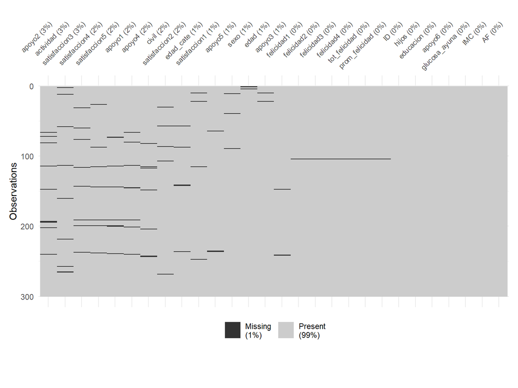

```r
library(ggplot2)
library(naniar)
vis_miss(datos,
         sort_miss = TRUE) + theme(axis.text.x = element_text(angle = 45,
                                                              hjust = 1,
                                                              vjust = 1,
                                                              size = 8),
                                   plot.margin = margin(t = 10,
                                                        r = 10,
                                                        b = 50,
                                                        l = 10))
```

También se puede obtener un resumen de los datos perdidos con **miss_var_summary()**.

```r
miss_var_summary(datos,
                 order = TRUE)
```

```
## # A tibble: 28 × 3
##    variable      n_miss pct_miss
##    <chr>          <int>    <num>
##  1 apoyo2             9     3
##  2 actividad          8     2.67
##  3 satisfaccion3      8     2.67
##  4 satisfaccion4      7     2.33
##  5 satisfaccion5      7     2.33
##  6 apoyo1             7     2.33
##  7 apoyo4             7     2.33
##  8 civil              5     1.67
##  9 satisfaccion2      5     1.67
## 10 edad_cate          4     1.33
## # ℹ 18 more rows
```

# Datos perdidos

Se puede filtrar excluyendo casos con datos perdidos en una variable.

```r
filter(datos,
       !is.na(edad))
```

```
## # A tibble: 298 × 28
##       ID sexo   edad hijos actividad educacion civil satisfaccion1 satisfaccion2
##    <dbl> <chr> <dbl> <chr> <chr>     <chr>     <chr> <chr>         <chr>
##  1   192 <NA>     24 No    Trabaja   Superior… Solt… De acuerdo    De acuerdo
##  2   193 Mujer    64 Sí    <NA>      Superior… Viud… Totalmente d… Totalmente d…
##  3   195 Mujer    32 No    Trabaja   Superior… Solt… Ligeramente … Ligeramente …
##  4   196 <NA>     22 No    Estudia   Media co… Solt… Ni de acuerd… En desacuerdo
##  5   197 Mujer    30 Sí    Estudia   Superior… Casa… Ligeramente … En desacuerdo
##  6   198 Mujer    23 No    Estudia   Superior… Solt… De acuerdo    Ligeramente …
##  7   199 Homb…    20 No    Desemple… Media co… Solt… Ni de acuerd… Ligeramente …
##  8   200 Mujer    23 No    Estudia   Superior… Solt… Ligeramente … Ligeramente …
##  9   201 Homb…    21 No    Estudia   Superior… Solt… Ligeramente … De acuerdo
## 10   203 Mujer    53 Sí    Jefe/a d… Básica c… Sepa… Totalmente e… Totalmente e…
## # ℹ 288 more rows
## # ℹ 19 more variables: satisfaccion3 <chr>, satisfaccion4 <chr>,
## #   satisfaccion5 <chr>, apoyo1 <dbl>, apoyo2 <dbl>, apoyo3 <dbl>,
## #   apoyo4 <dbl>, apoyo5 <dbl>, apoyo6 <dbl>, felicidad1 <dbl>,
## #   felicidad2 <dbl>, felicidad3 <dbl>, felicidad4 <dbl>, glucosa_ayuna <dbl>,
## #   IMC <dbl>, AF <dbl>, tot_felicidad <dbl>, prom_felicidad <dbl>,
## #   edad_cate <dbl>
```

También es posible remover todos los casos con datos perdidos de un dataset con la función **complete.cases()**.

```r
filter(datos,
       complete.cases(datos))
```

```
## # A tibble: 238 × 28
##       ID sexo   edad hijos actividad educacion civil satisfaccion1 satisfaccion2
##    <dbl> <chr> <dbl> <chr> <chr>     <chr>     <chr> <chr>         <chr>
##  1   195 Mujer    32 No    Trabaja   Superior… Solt… Ligeramente … Ligeramente …
##  2   197 Mujer    30 Sí    Estudia   Superior… Casa… Ligeramente … En desacuerdo
##  3   198 Mujer    23 No    Estudia   Superior… Solt… De acuerdo    Ligeramente …
##  4   199 Homb…    20 No    Desemple… Media co… Solt… Ni de acuerd… Ligeramente …
##  5   200 Mujer    23 No    Estudia   Superior… Solt… Ligeramente … Ligeramente …
##  6   201 Homb…    21 No    Estudia   Superior… Solt… Ligeramente … De acuerdo
##  7   205 Homb…    33 No    Trabaja   Superior… Solt… Ligeramente … De acuerdo
##  8   206 Mujer    37 Sí    Trabaja   Superior… Solt… Ligeramente … Ligeramente …
##  9   207 Mujer    29 Sí    Estudia … Media co… Solt… De acuerdo    Ni de acuerd…
## 10   208 Mujer    19 No    Estudia   Media co… Solt… De acuerdo    Ni de acuerd…
## # ℹ 228 more rows
## # ℹ 19 more variables: satisfaccion3 <chr>, satisfaccion4 <chr>,
## #   satisfaccion5 <chr>, apoyo1 <dbl>, apoyo2 <dbl>, apoyo3 <dbl>,
## #   apoyo4 <dbl>, apoyo5 <dbl>, apoyo6 <dbl>, felicidad1 <dbl>,
## #   felicidad2 <dbl>, felicidad3 <dbl>, felicidad4 <dbl>, glucosa_ayuna <dbl>,
## #   IMC <dbl>, AF <dbl>, tot_felicidad <dbl>, prom_felicidad <dbl>,
## #   edad_cate <dbl>
```

# Combinación de operaciones con el operador pipe (%>%)

El operador **%>%** (ctrl + shift + m) permite combinar distintas operaciones al mismo tiempo. Funciona como una **línea de ensamblaje**.

**%>%** toma el objeto a la izquierda y lo pasa como el primer argumento de la función especificada a la derecha.

```r
filter(datos,
       sexo == "Mujer")
```

```
## # A tibble: 179 × 28
##       ID sexo   edad hijos actividad educacion civil satisfaccion1 satisfaccion2
##    <dbl> <chr> <dbl> <chr> <chr>     <chr>     <chr> <chr>         <chr>
##  1   193 Mujer    64 Sí    <NA>      Superior… Viud… Totalmente d… Totalmente d…
##  2   195 Mujer    32 No    Trabaja   Superior… Solt… Ligeramente … Ligeramente …
##  3   197 Mujer    30 Sí    Estudia   Superior… Casa… Ligeramente … En desacuerdo
##  4   198 Mujer    23 No    Estudia   Superior… Solt… De acuerdo    Ligeramente …
##  5   200 Mujer    23 No    Estudia   Superior… Solt… Ligeramente … Ligeramente …
##  6   203 Mujer    53 Sí    Jefe/a d… Básica c… Sepa… Totalmente e… Totalmente e…
##  7   204 Mujer    23 No    <NA>      Superior… Solt… Ligeramente … De acuerdo
##  8   206 Mujer    37 Sí    Trabaja   Superior… Solt… Ligeramente … Ligeramente …
##  9   207 Mujer    29 Sí    Estudia … Media co… Solt… De acuerdo    Ni de acuerd…
## 10   208 Mujer    19 No    Estudia   Media co… Solt… De acuerdo    Ni de acuerd…
## # ℹ 169 more rows
## # ℹ 19 more variables: satisfaccion3 <chr>, satisfaccion4 <chr>,
## #   satisfaccion5 <chr>, apoyo1 <dbl>, apoyo2 <dbl>, apoyo3 <dbl>,
## #   apoyo4 <dbl>, apoyo5 <dbl>, apoyo6 <dbl>, felicidad1 <dbl>,
## #   felicidad2 <dbl>, felicidad3 <dbl>, felicidad4 <dbl>, glucosa_ayuna <dbl>,
## #   IMC <dbl>, AF <dbl>, tot_felicidad <dbl>, prom_felicidad <dbl>,
## #   edad_cate <dbl>
```

```r
# Es lo mismo que...

datos %>% filter(sexo == "Mujer")
```

```
## # A tibble: 179 × 28
##       ID sexo   edad hijos actividad educacion civil satisfaccion1 satisfaccion2
##    <dbl> <chr> <dbl> <chr> <chr>     <chr>     <chr> <chr>         <chr>
##  1   193 Mujer    64 Sí    <NA>      Superior… Viud… Totalmente d… Totalmente d…
##  2   195 Mujer    32 No    Trabaja   Superior… Solt… Ligeramente … Ligeramente …
##  3   197 Mujer    30 Sí    Estudia   Superior… Casa… Ligeramente … En desacuerdo
##  4   198 Mujer    23 No    Estudia   Superior… Solt… De acuerdo    Ligeramente …
##  5   200 Mujer    23 No    Estudia   Superior… Solt… Ligeramente … Ligeramente …
##  6   203 Mujer    53 Sí    Jefe/a d… Básica c… Sepa… Totalmente e… Totalmente e…
##  7   204 Mujer    23 No    <NA>      Superior… Solt… Ligeramente … De acuerdo
##  8   206 Mujer    37 Sí    Trabaja   Superior… Solt… Ligeramente … Ligeramente …
##  9   207 Mujer    29 Sí    Estudia … Media co… Solt… De acuerdo    Ni de acuerd…
## 10   208 Mujer    19 No    Estudia   Media co… Solt… De acuerdo    Ni de acuerd…
## # ℹ 169 more rows
## # ℹ 19 more variables: satisfaccion3 <chr>, satisfaccion4 <chr>,
## #   satisfaccion5 <chr>, apoyo1 <dbl>, apoyo2 <dbl>, apoyo3 <dbl>,
## #   apoyo4 <dbl>, apoyo5 <dbl>, apoyo6 <dbl>, felicidad1 <dbl>,
## #   felicidad2 <dbl>, felicidad3 <dbl>, felicidad4 <dbl>, glucosa_ayuna <dbl>,
## #   IMC <dbl>, AF <dbl>, tot_felicidad <dbl>, prom_felicidad <dbl>,
## #   edad_cate <dbl>
```

# Combinación de operaciones con el operador pipe (%>%)

- Se filtran a las mujeres sin hijos.
- Se selecciona el puntaje total de felicidad y los ítems de apoyo social.
- Se crea un puntaje total de apoyo social percibido.
- Se eliminan los casos con datos perdidos.

```r
datos %>% filter(sexo == "Mujer" & hijos == "No") %>%
          select(tot_felicidad, apoyo1, apoyo2, apoyo3, apoyo4, apoyo5, apoyo6) %>%
          mutate(tot_apoyo = apoyo1 + apoyo2 + apoyo3 + apoyo4 + apoyo5 + apoyo6) %>%
          filter(complete.cases(.))
```

```
## # A tibble: 72 × 8
##    tot_felicidad apoyo1 apoyo2 apoyo3 apoyo4 apoyo5 apoyo6 tot_apoyo
##            <dbl>  <dbl>  <dbl>  <dbl>  <dbl>  <dbl>  <dbl>     <dbl>
##  1            21      5      5      5      5      5      5        30
##  2            16      4      4      4      4      4      4        24
##  3            22      4      5      5      1      5      5        25
##  4            16      4      4      5      3      4      5        25
##  5            11      4      5      5      3      4      4        25
##  6            16      3      3      3      3      3      3        18
##  7            18      5      5      4      4      5      5        28
##  8            22      5      5      5      5      5      5        30
##  9            14      3      3      4      3      2      3        18
## 10            23      3      2      3      1      3      4        16
## # ℹ 62 more rows
```